# Simulated data

```r
library(leaps)
```

In this data set I will generate a simulated data from a known model. The model is to predict the salary of a person as a function of years of experience, number of job changes before, and years since job changed. We will also add a dummy variable which does not affect the Salary, something like number of children.

So, we assume that the model is as follows. Salary = 3 + 3 * Exp + 0.5 * Jobs + 4 * CJobExp + 0 * Children + Error

Experience, Jobs, and CJobExp are going to be randomly generated. We just generate 20 samples.

```r
set.seed(1)
Exp = floor(runif(20)*10);
print(Exp)
```

```
##  [1] 2 3 5 9 2 8 9 6 6 0 2 1 6 3 7 4 7 9 3 7
```

```r
Jobs = round(runif(20)*10, 1)
print(Jobs)
```

```
##  [1] 9.3 2.1 6.5 1.3 2.7 3.9 0.1 3.8 8.7 3.4 4.8 6.0 4.9 1.9 8.3 6.7 7.9
## [18] 1.1 7.2 4.1
```

```r
CJobExp = round(runif(20)*10, 1)
print(CJobExp)
```

```
##  [1] 8.2 6.5 7.8 5.5 5.3 7.9 0.2 4.8 7.3 6.9 4.8 8.6 4.4 2.4 0.7 1.0 3.2
## [18] 5.2 6.6 4.1
```

```r
Children = floor(runif(20)*5)
print(Children)
```

```
##  [1] 4 1 2 1 3 1 2 3 0 4 1 4 1 1 2 4 4 1 3 4
```

```r
error = rnorm(20, 0, 1)
print(error)
```

```
##  [1] -0.1645236 -0.2533617  0.6969634  0.5566632 -0.6887557 -0.7074952
##  [7]  0.3645820  0.7685329 -0.1123462  0.8811077  0.3981059 -0.6120264
## [13]  0.3411197 -1.1293631  1.4330237  1.9803999 -0.3672215 -1.0441346
## [19]  0.5697196 -0.1350546
```

I will now generate the Salary.

```r
Salary = 3 + 3 * Exp + 0.5 * Jobs + 4 * CJobExp + 0 * Children + error
print(Salary)
```

```
##  [1] 46.28548 38.79664 53.14696 53.20666 30.86124 59.84250 31.21458
##  [8] 42.86853 54.43765 33.18111 30.99811 42.78797 41.39112 21.42064
## [15] 32.38302 24.33040 40.38278 50.30587 42.56972 42.31495
```

This is the complete data.

```r
data = data.frame(Exp, Jobs, CJobExp, Children, Salary)
print(data)
```

```
##    Exp Jobs CJobExp Children   Salary
## 1    2  9.3     8.2        4 46.28548
## 2    3  2.1     6.5        1 38.79664
## 3    5  6.5     7.8        2 53.14696
## 4    9  1.3     5.5        1 53.20666
## 5    2  2.7     5.3        3 30.86124
## 6    8  3.9     7.9        1 59.84250
## 7    9  0.1     0.2        2 31.21458
## 8    6  3.8     4.8        3 42.86853
## 9    6  8.7     7.3        0 54.43765
## 10   0  3.4     6.9        4 33.18111
## 11   2  4.8     4.8        1 30.99811
## 12   1  6.0     8.6        4 42.78797
## 13   6  4.9     4.4        1 41.39112
## 14   3  1.9     2.4        1 21.42064
## 15   7  8.3     0.7        2 32.38302
## 16   4  6.7     1.0        4 24.33040
## 17   7  7.9     3.2        4 40.38278
## 18   9  1.1     5.2        1 50.30587
## 19   3  7.2     6.6        3 42.56972
## 20   7  4.1     4.1        4 42.31495
```

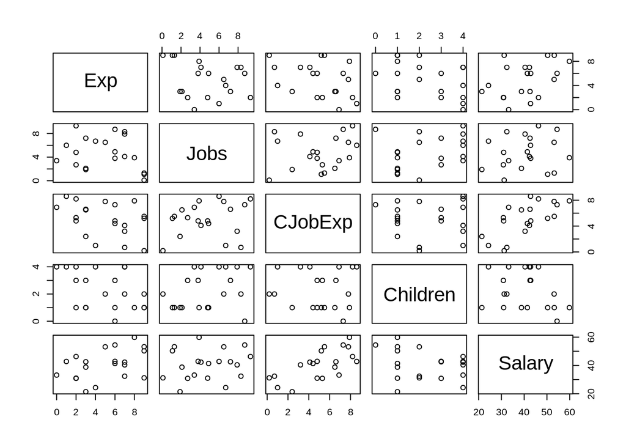

```r
pairs(data)
```

[figure not shown]

```r
corrgram::corrgram(data)
```

The correlation of features with salary is as expected because the data comes from a predecided model.

```r
trainIndices = sample(seq(20), 15, replace = FALSE)
trainingData = data[trainIndices, ]
print(trainingData)
```

```
##    Exp Jobs CJobExp Children   Salary
## 20   7  4.1     4.1        4 42.31495
## 10   0  3.4     6.9        4 33.18111
## 9    6  8.7     7.3        0 54.43765
## 3    5  6.5     7.8        2 53.14696
## 13   6  4.9     4.4        1 41.39112
## 7    9  0.1     0.2        2 31.21458
## 8    6  3.8     4.8        3 42.86853
## 17   7  7.9     3.2        4 40.38278
## 16   4  6.7     1.0        4 24.33040
## 15   7  8.3     0.7        2 32.38302
## 6    8  3.9     7.9        1 59.84250
## 1    2  9.3     8.2        4 46.28548
## 18   9  1.1     5.2        1 50.30587
## 5    2  2.7     5.3        3 30.86124
## 19   3  7.2     6.6        3 42.56972
```

This is the test data.

```r
validationData = data[-trainIndices, ]
print(validationData)
```

```
##    Exp Jobs CJobExp Children   Salary
## 2    3  2.1     6.5        1 38.79664
## 4    9  1.3     5.5        1 53.20666
## 11   2  4.8     4.8        1 30.99811
## 12   1  6.0     8.6        4 42.78797
## 14   3  1.9     2.4        1 21.42064
```

Let us use forward subset selection to get models of various sizes.

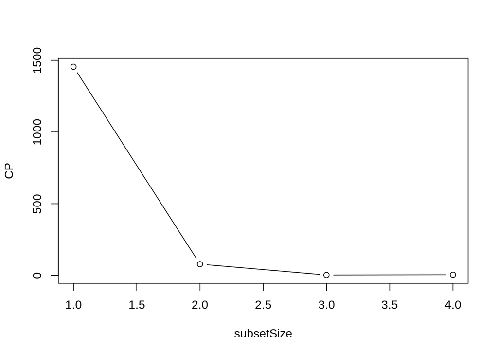

```r
trainingSetFit = regsubsets(Salary ~ ., trainingData, nvmax = 4, method = "forward")
trainSummary = summary(trainingSetFit)
subsetSize = 1:4
plot(subsetSize, trainSummary$cp, ylab = "CP", type = "b")
```

CP, helps us estimate the test error. The lower it is, the better. If it flattens out, it is better to choose a model with less number of features. Here are the actual values of CP.

```r
trainSummary$cp
```

```
## [1] 1455.279830   78.870254    3.386612    5.000000
```

The CP values clearly indicate that we do not need a model with the 4th feature. But, what is that 4th feature? Let us look at the coefficients.

```r
coef(trainingSetFit, 1)
```

```
## (Intercept)     CJobExp
##   28.249637    2.741459
```

```r
coef(trainingSetFit, 2)
```

```
## (Intercept)         Exp     CJobExp
##    8.242012    2.701798    3.845653
```

```r
coef(trainingSetFit, 3)
```

```
## (Intercept)         Exp        Jobs     CJobExp
##   4.6178600   2.8571857   0.5879933   3.7853220
```

```r
coef(trainingSetFit, 4)
```

```
## (Intercept)         Exp        Jobs     CJobExp    Children
##   5.2278333   2.8178430   0.5889784   3.7603454  -0.1105788
```

No surprises, it is the ‘Children’ feature.

Now, let us pass through each of these models the validation set data that we separated out.

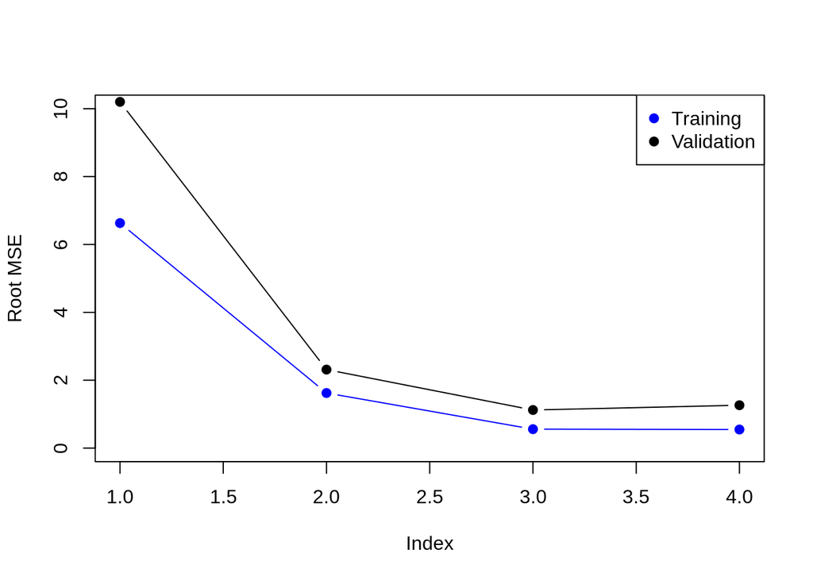

```r
testErrors = rep(NA, 19)
testMatrix = model.matrix(Salary ~ ., validationData)
for(i in 1:4){
  coefi = coef(trainingSetFit, id = i)
  subset = testMatrix[, names(coefi)]
  predictions = subset%*%coefi
  testErrors[i] = mean((validationData$Salary - predictions)^2)
}
plot(sqrt(testErrors), ylab="Root MSE", pch=19, type="b", ylim=range(0,10), xlim=range(1, 4))
trainRssMeans = trainingSetFit$rss[-1] / 15
points(sqrt(trainRssMeans), col = "blue", pch = 19, type = "b")
legend("topright", legend = c("Training", "Validation"), col=c("blue","black"), pch=19)
```

As expected, the validation/test error is more than the training error. Both, validation set and Cp indicate that the better model is the following with the 3 variables.

```r
coef(trainingSetFit, 3)
```

```
## (Intercept)         Exp        Jobs     CJobExp
##   4.6178600   2.8571857   0.5879933   3.7853220
```

The above is also very close to the true population model.

Salary = 3 + 3 * Exp + 0.5 * Jobs + 4 * CJobExp + 0 * Children + Error